# Nexo entre crecimiento económico y desarrollo del sistema financiero: análisis de cointegración y series de tiempo, para el caso de Costa Rica.

Fabián Brenes Trejos

4/5/2021

El objetivo del estudio consiste en estudiar la relación entre el **crecimiento económico** (representado por el PIB real) y el **desarrollo del sistema financiero** (se utiliza como variable proxy los créditos al sector privado en porcentajes del PIB nominal), mediante modelos multivariados temporales.

## PIB Real de Costa Rica

- Fuente primaria: Banco Central de Costa Rica
- Unidad de medida: Millones de colones encadenados

[interactive chart not shown]

### Análisis de Estacionariedad serie original

El resultado de la prueba de raíz unitaria de Dickey-Fuller, aporta evidencia suficiente para rechazar la hipótesis nula de que la serie no es estacionaria, con un nivel de significancia de 1%. Sin embargo, por la forma del autocorrelograma, se concluye que la **serie es no estacionaria de orden 0**.

```
##
## ###############################################
## # Augmented Dickey-Fuller Test Unit Root Test #
## ###############################################
##
## Test regression trend
##
##
## Call:
## lm(formula = z.diff ~ z.lag.1 + 1 + tt + z.diff.lag)
##
## Residuals:
##     Min      1Q  Median      3Q     Max
## -929522 -108182   -6439  110868  422654
##
## Coefficients:
##               Estimate Std. Error t value Pr(>|t|)
## (Intercept)  2.839e+06  4.472e+05   6.348 1.33e-08 ***
## z.lag.1     -7.118e-01  1.145e-01  -6.219 2.31e-08 ***
## tt           4.491e+04  7.311e+03   6.143 3.18e-08 ***
## z.diff.lag   3.822e-01  1.195e-01   3.199  0.00199 **
## ---
## Signif. codes:  0 '***' 0.001 '**' 0.01 '*' 0.05 '.' 0.1 ' ' 1
##
## Residual standard error: 187800 on 78 degrees of freedom
## Multiple R-squared:  0.3332, Adjusted R-squared:  0.3076
## F-statistic: 12.99 on 3 and 78 DF,  p-value: 5.743e-07
##
##
## Value of test-statistic is: -6.2185 15.7094 19.3668
##
## Critical values for test statistics:
##       1pct  5pct 10pct
## tau3 -4.04 -3.45 -3.15
## phi2  6.50  4.88  4.16
## phi3  8.73  6.49  5.47
```

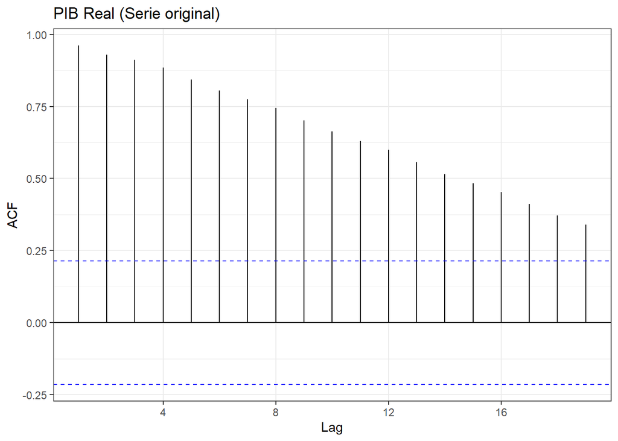

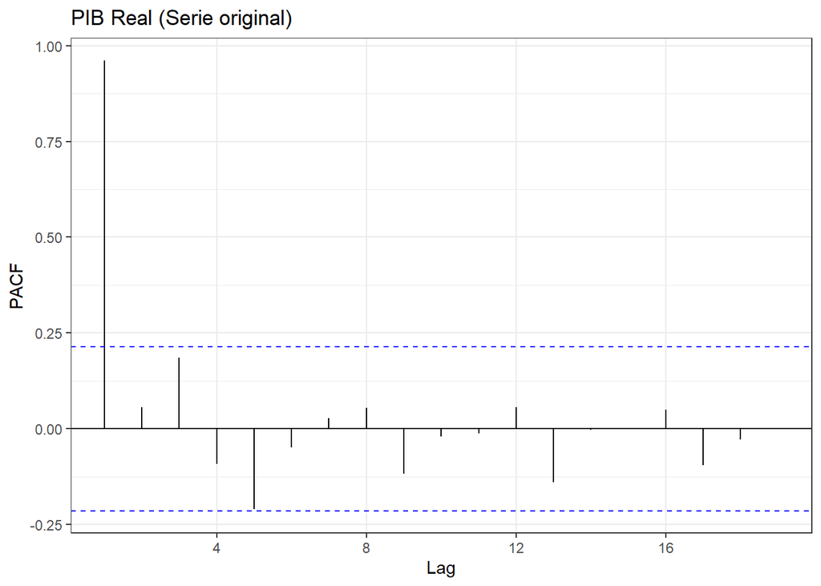

### Estacionariedad serie en primeras diferencias

Con el autocorrelograma se comprueba que el PIB real de Costa Rica es estacionario de orden 1.

```
##
## ###############################################
## # Augmented Dickey-Fuller Test Unit Root Test #
## ###############################################
##
## Test regression none
##
##
## Call:
## lm(formula = z.diff ~ z.lag.1 - 1 + z.diff.lag)
##
## Residuals:
##     Min      1Q  Median      3Q     Max
## -678403    8204   75516  182584  417675
##
## Coefficients:
##            Estimate Std. Error t value Pr(>|t|)
## z.lag.1    -1.64143    0.13484 -12.174  < 2e-16 ***
## z.diff.lag  0.64897    0.09454   6.865 1.36e-09 ***
## ---
## Signif. codes:  0 '***' 0.001 '**' 0.01 '*' 0.05 '.' 0.1 ' ' 1
##
## Residual standard error: 187000 on 79 degrees of freedom
## Multiple R-squared:  0.6616, Adjusted R-squared:  0.6531
## F-statistic: 77.23 on 2 and 79 DF,  p-value: < 2.2e-16
##
##
## Value of test-statistic is: -12.1735
##
## Critical values for test statistics:
##      1pct  5pct 10pct
## tau1 -2.6 -1.95 -1.61
```

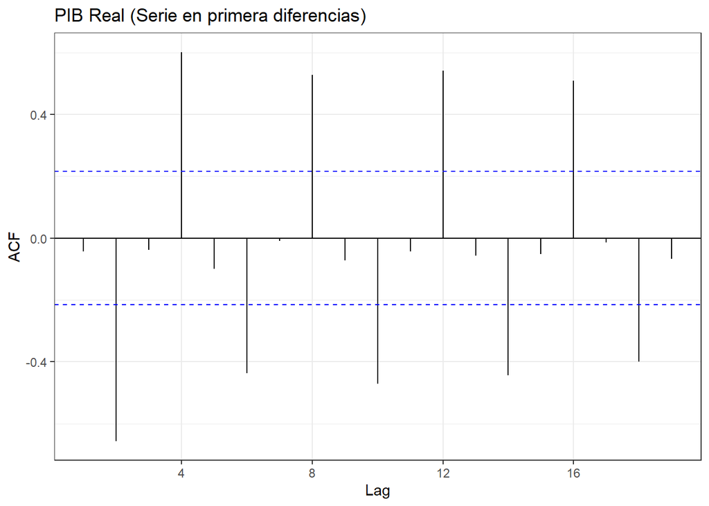

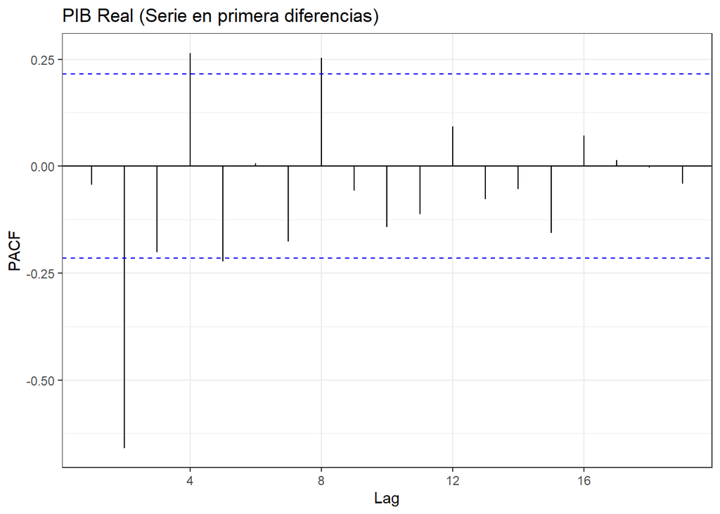

## Créditos al sector privado

- Fuente primaria: Banco Central de Costa Rica
- Unidad de medida: Porcentaje del PIB nominal

[interactive chart not shown]

### Estacionariedad serie original

Con base a la prueba Dickey Fuller, no existe suficiente evidencia estadística para rechazar la hipótesis nula de que la serie es no estacionaria, con un nivel de significancia del 1%. De igual manera, con el correlograma de la serie se concluye lo mismo, por tanto la **serie es no estacionaria de orden 0**.

```
##
## ###############################################
## # Augmented Dickey-Fuller Test Unit Root Test #
## ###############################################
##
## Test regression trend
##
##
## Call:
## lm(formula = z.diff ~ z.lag.1 + 1 + tt + z.diff.lag)
##
## Residuals:
##        Min         1Q     Median         3Q        Max
## -0.0258400 -0.0050351  0.0005978  0.0056495  0.0173791
##
## Coefficients:
##               Estimate Std. Error t value Pr(>|t|)
## (Intercept)  0.0241461  0.0088960   2.714 0.008173 **
## z.lag.1     -0.0832442  0.0353007  -2.358 0.020872 *
## tt           0.0003426  0.0001594   2.149 0.034750 *
## z.diff.lag   0.4205232  0.1035519   4.061 0.000115 ***
## ---
## Signif. codes:  0 '***' 0.001 '**' 0.01 '*' 0.05 '.' 0.1 ' ' 1
##
## Residual standard error: 0.007959 on 78 degrees of freedom
## Multiple R-squared:  0.2073, Adjusted R-squared:  0.1768
## F-statistic: 6.799 on 3 and 78 DF,  p-value: 0.0003937
##
##
## Value of test-statistic is: -2.3581 4.4289 2.9664
##
## Critical values for test statistics:
##       1pct  5pct 10pct
## tau3 -4.04 -3.45 -3.15
## phi2  6.50  4.88  4.16
## phi3  8.73  6.49  5.47
```

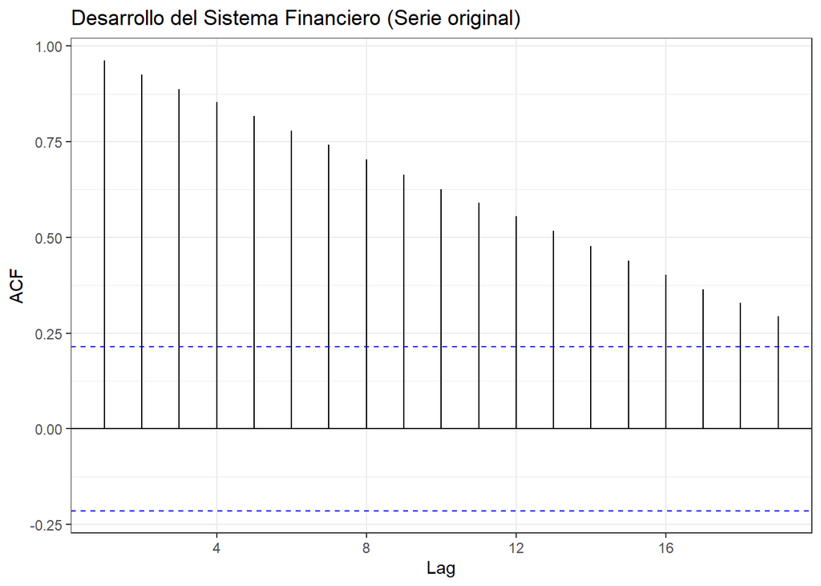

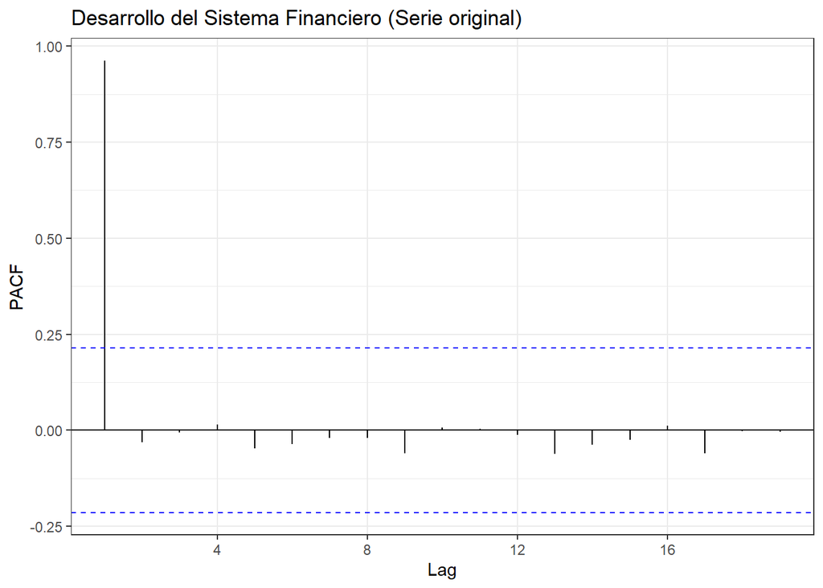

### Estacionariedad serie en primeras diferencias

Tanto con la prueba Dickey Fuller, en donde existe evidencia estadística para rechazar la hipótesis nula de que la serie en primeras diferencias es no estacionaria con un nivel de significancia del 1%, como con el autocorrelograma, se concluye que la serie en primeras diferencias es estacionario, es decir, el desarrollo del sistema financiero es **estacionaria de orden 1**

```
##
## ###############################################
## # Augmented Dickey-Fuller Test Unit Root Test #
## ###############################################
##
## Test regression none
##
##
## Call:
## lm(formula = z.diff ~ z.lag.1 - 1 + z.diff.lag)
##
## Residuals:
##       Min        1Q    Median        3Q       Max
## -0.026633 -0.003109  0.003224  0.007219  0.016845
##
## Coefficients:
##            Estimate Std. Error t value Pr(>|t|)
## z.lag.1     -0.4306     0.1129  -3.814  0.00027 ***
## z.diff.lag  -0.1291     0.1132  -1.141  0.25752
## ---
## Signif. codes:  0 '***' 0.001 '**' 0.01 '*' 0.05 '.' 0.1 ' ' 1
##
## Residual standard error: 0.008485 on 79 degrees of freedom
## Multiple R-squared:  0.2587, Adjusted R-squared:  0.2399
## F-statistic: 13.78 on 2 and 79 DF,  p-value: 7.333e-06
##
##
## Value of test-statistic is: -3.8138
##
## Critical values for test statistics:
##      1pct  5pct 10pct
## tau1 -2.6 -1.95 -1.61
```

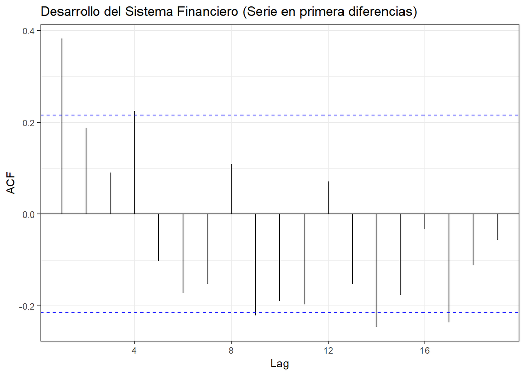

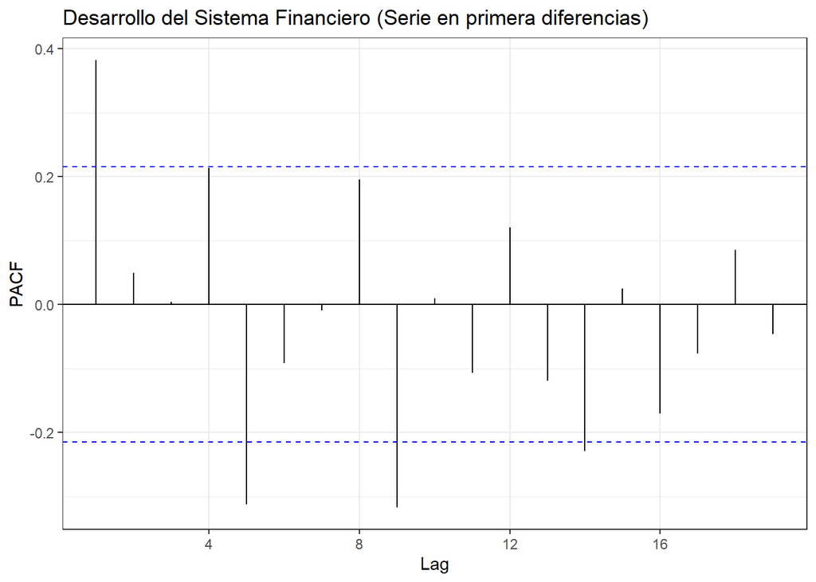

## Análisis Descriptivo

### Correlación entre PIBr y Créditos al sector privado

[interactive chart not shown]

Las variables en niveles muestran un alto nivel de correlación de 0.97.

Al correr una regresión lineal simple entre el PIB real en función del desarrollo del sistema financiero y gráficar los residuos estandarizados, se observan que en el periodo de la crisis financiera mundial (2008 y 2009), estos valores son mayor a 2 en valor absoluto. De igual manera, para diciembre 2019 el residuo estandarizado es mayor a 2.

### Variables de control

| Indicador | Nombre Completo | Unidad | Estadísticas Descriptivas Promedio | Estadísticas Descriptivas Mínimo | Estadísticas Descriptivas Máximo | Estadísticas Descriptivas Desviación Estándar | Estadísticas Descriptivas Coeficiente de Variación |
| --- | --- | --- | --- | --- | --- | --- | --- |
| apert_comercial | Apertura Comercial | % del PIB | 73.9 | 57.1 | 94.4 | 11.0 | 0.149 |
| ied | Inversión Extranjera Directa | Millones de USD | 467.7 | 82.6 | 1212.3 | 243.1 | 0.520 |
| inflacion | Inflación | % | 6.7 | -1.1 | 15.8 | 4.6 | 0.687 |

* Fuente: Banco Central de Costa Rica

### Gráficos de las Variables en Niveles

[interactive chart not shown]

### Gráficos de Dispersión vrs PIBr

[interactive chart not shown]

### Gráficos de Dispersión vrs Desarrollo del Sistema Financiero

[interactive chart not shown]

### Regresión Lineal (variable dependiente = PIBr)

Ecuación: pibr ~ cred_pib+apert_comercial+ied+inflacion

```r
mod_lm_pib <- lm(formula_mod_lineal_pib, data = data)
summary(mod_lm_pib)
```

```
##
## Call:
## lm(formula = formula_mod_lineal_pib, data = data)
##
## Residuals:
##     Min      1Q  Median      3Q     Max
## -888236 -180336     955  157705  802236
##
## Coefficients:
##                   Estimate Std. Error t value Pr(>|t|)
## (Intercept)      2412366.9   590239.4   4.087 0.000104 ***
## cred_pib        10454830.1   615367.1  16.990  < 2e-16 ***
## apert_comercial    -2794.0     7028.6  -0.398 0.692055
## ied                  617.4      180.1   3.428 0.000969 ***
## inflacion         -63069.9    17203.9  -3.666 0.000445 ***
## ---
## Signif. codes:  0 '***' 0.001 '**' 0.01 '*' 0.05 '.' 0.1 ' ' 1
##
## Residual standard error: 301300 on 79 degrees of freedom
## Multiple R-squared:  0.9637, Adjusted R-squared:  0.9619
## F-statistic: 524.3 on 4 and 79 DF,  p-value: < 2.2e-16
```

#### Evaluación de los supuestos del modelo

##### 1. Multicolinealidad

Las covariables no presentan una alta multicolinealidad.

```r
vif(mod_lm_pib)
```

```
##        cred_pib apert_comercial             ied       inflacion
##        4.144786        5.453756        1.753324        5.683591
```

##### 2. Homocedasticidad

No se cumple el supuesto de homocedasticidad, con base a la prueba Breusch-Pagan.

```r
bptest(mod_lm_pib)
```

```
##
##  studentized Breusch-Pagan test
##
## data:  mod_lm_pib
## BP = 15.057, df = 4, p-value = 0.004585
```

##### 3. Autocorrelación en los residuos

El modelo presenta autocorrelación en el residuo.

```r
bgtest(mod_lm_pib)
```

```
##
##  Breusch-Godfrey test for serial correlation of order up to 1
##
## data:  mod_lm_pib
## LM test = 39.86, df = 1, p-value = 2.728e-10
```

##### 4. Normalidad de los residuos

```r
shapiro.test(mod_lm_pib$residuals)
```

```
##
##  Shapiro-Wilk normality test
##
## data:  mod_lm_pib$residuals
## W = 0.97728, p-value = 0.1436
```

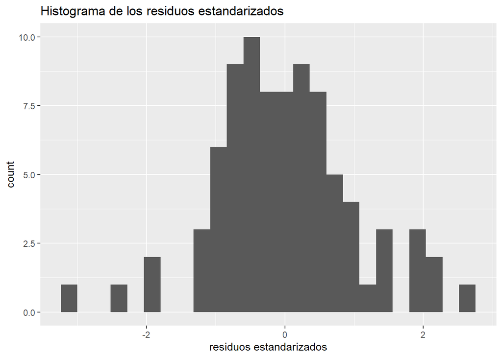

```r
tibble(`residuos estandarizados` = scale(mod_lm_pib$residuals)) %>%
  ggplot(aes(x = `residuos estandarizados`)) + geom_histogram(bins = 25) +
  ggtitle("Histograma de los residuos estandarizados")
```

### Regresión Lineal (variable dependiente = desarrollo del sistema financiero)

Ecuación: cred_pib ~ pibr +apert_comercial+ied+inflacion

```r
mod_lm_dsf <- lm(formula_mod_lineal_dsf, data = data)
summary(mod_lm_dsf)
```

```
##
## Call:
## lm(formula = formula_mod_lineal_dsf, data = data)
##
## Residuals:
##       Min        1Q    Median        3Q       Max
## -0.058248 -0.016185 -0.001673  0.011543  0.077094
##
## Coefficients:
##                   Estimate Std. Error t value Pr(>|t|)
## (Intercept)     -3.920e-02  5.488e-02  -0.714   0.4771
## pibr             7.510e-08  4.420e-09  16.990   <2e-16 ***
## apert_comercial -4.713e-04  5.939e-04  -0.794   0.4298
## ied             -1.571e-05  1.626e-05  -0.966   0.3371
## inflacion        2.850e-03  1.544e-03   1.845   0.0687 .
## ---
## Signif. codes:  0 '***' 0.001 '**' 0.01 '*' 0.05 '.' 0.1 ' ' 1
##
## Residual standard error: 0.02553 on 79 degrees of freedom
## Multiple R-squared:  0.9482, Adjusted R-squared:  0.9455
## F-statistic: 361.2 on 4 and 79 DF,  p-value: < 2.2e-16
```

#### Evaluación de los supuestos del modelo

##### 1. Multicolinealidad

Las covariables no presentan una alta multicolinealidad.

```r
vif(mod_lm_dsf)
```

```
##            pibr apert_comercial             ied       inflacion
##        5.919412        5.421452        1.990622        6.375682
```

##### 2. Homocedasticidad

Sí se cumple el supuesto de homocedasticidad, con base a la prueba Breusch-Pagan.

```r
bptest(mod_lm_dsf)
```

```
##
##  studentized Breusch-Pagan test
##
## data:  mod_lm_dsf
## BP = 6.9278, df = 4, p-value = 0.1398
```

##### 3. Autocorrelación en los residuos

El modelo presenta autocorrelación en el residuo.

```r
bgtest(mod_lm_dsf)
```

```
##
##  Breusch-Godfrey test for serial correlation of order up to 1
##
## data:  mod_lm_dsf
## LM test = 46.604, df = 1, p-value = 8.689e-12
```

##### 4. Normalidad de los residuos

Los residuos del modelo no siguen una distribución normal.

```r
shapiro.test(mod_lm_dsf$residuals)
```

```
##
##  Shapiro-Wilk normality test
##
## data:  mod_lm_dsf$residuals
## W = 0.96733, p-value = 0.03128
```

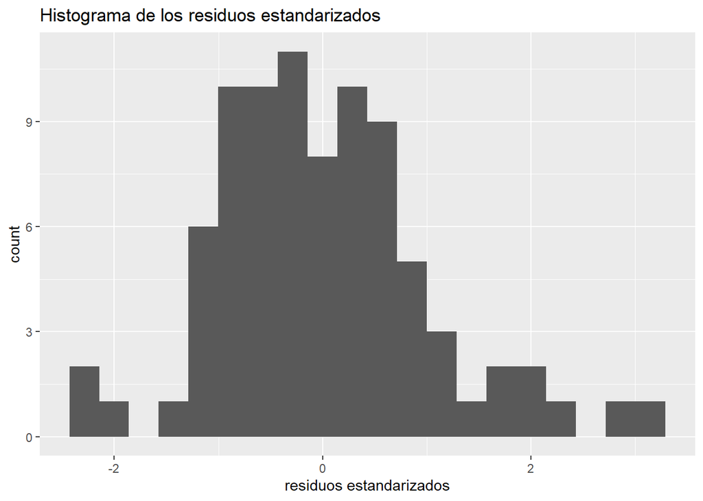

```r
tibble(`residuos estandarizados` = scale(mod_lm_dsf$residuals)) %>%
  ggplot(aes(x = `residuos estandarizados`)) + geom_histogram(bins = 20) +
  ggtitle("Histograma de los residuos estandarizados")
```

## Cointegración

A continuación se calcula la regresión lineal del **PIBr** en función del **desarrollo del sistema financiero** y se evalúa el residuo. Según se constató previamente, ambas series son estacionarias de orden 1. Por tanto, si el residuo es estacionario de orden inferior, se concluye que las series cointegran.

```r
mod_lin <- lm(pibr ~ cred_pib, data = data)
summary(mod_lin)
```

```
##
## Call:
## lm(formula = pibr ~ cred_pib, data = data)
##
## Residuals:
##      Min       1Q   Median       3Q      Max
## -1070070  -151377    14167   211511   997524
##
## Coefficients:
##             Estimate Std. Error t value Pr(>|t|)
## (Intercept)   657556     162761    4.04  0.00012 ***
## cred_pib    13711026     363494   37.72  < 2e-16 ***
## ---
## Signif. codes:  0 '***' 0.001 '**' 0.01 '*' 0.05 '.' 0.1 ' ' 1
##
## Residual standard error: 362300 on 82 degrees of freedom
## Multiple R-squared:  0.9455, Adjusted R-squared:  0.9448
## F-statistic:  1423 on 1 and 82 DF,  p-value: < 2.2e-16
```

### Estacionariedad del Residuo

La prueba de Dickey Fuller rechaza la hipótesis nula de que el residuo de la regresión lineal del PIBr en función del desarrollo del sistema financiero es no estacionaria. Esto también se corrobora con el autocorrelograma, por lo cual el residuo es **estacionario de orden 0**, siendo el nivel de integración menor al de las series incluidas en la regresión, concluyéndose que ambas series cointegran en el largo plazo.

```r
ur.df(res_ts, selectlags = "AIC", type = "drift") %>%
  summary()
```

```
##
## ###############################################
## # Augmented Dickey-Fuller Test Unit Root Test #
## ###############################################
##
## Test regression drift
##
##
## Call:
## lm(formula = z.diff ~ z.lag.1 + 1 + z.diff.lag)
##
## Residuals:
##     Min      1Q  Median      3Q     Max
## -844524 -127956  -16711  140696  620225
##
## Coefficients:
##               Estimate Std. Error t value Pr(>|t|)
## (Intercept)  9.697e+02  2.381e+04   0.041 0.967613
## z.lag.1     -2.597e-01  6.999e-02  -3.710 0.000384 ***
## z.diff.lag   2.631e-01  1.114e-01   2.361 0.020690 *
## ---
## Signif. codes:  0 '***' 0.001 '**' 0.01 '*' 0.05 '.' 0.1 ' ' 1
##
## Residual standard error: 215300 on 79 degrees of freedom
## Multiple R-squared:  0.1635, Adjusted R-squared:  0.1423
## F-statistic: 7.719 on 2 and 79 DF,  p-value: 0.0008667
##
##
## Value of test-statistic is: -3.71 6.8853
##
## Critical values for test statistics:
##       1pct  5pct 10pct
## tau2 -3.51 -2.89 -2.58
## phi1  6.70  4.71  3.86
```

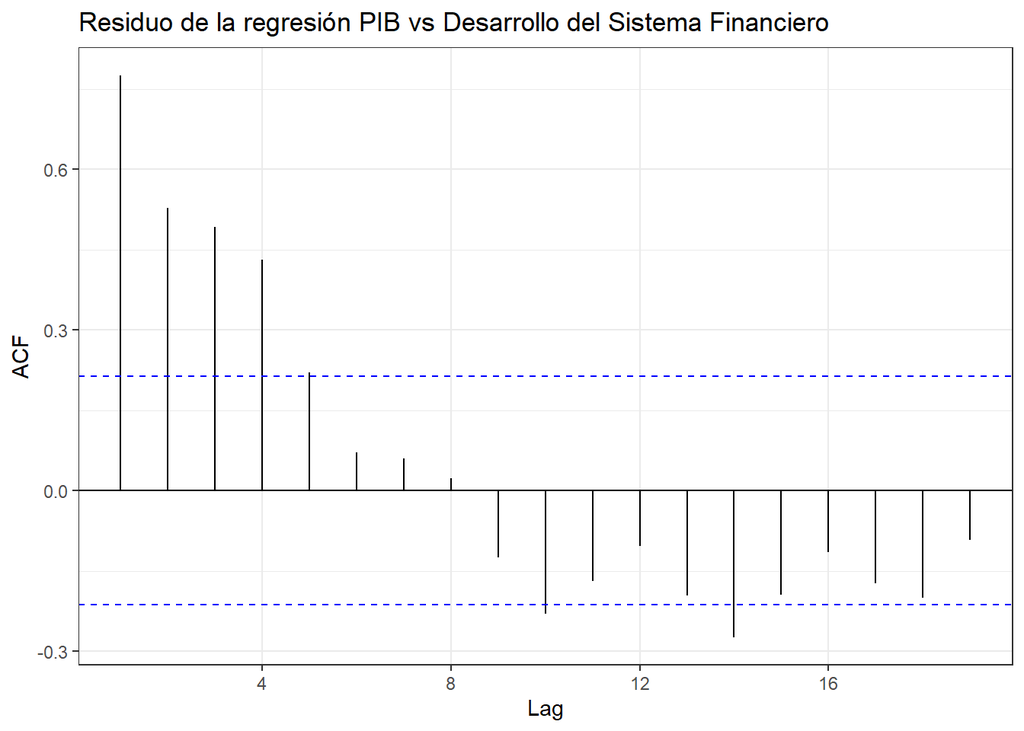

```r
#Correlogramas
ggAcf(res_ts) +
  ggtitle("Residuo de la regresión PIB vs Desarrollo del Sistema Financiero") +
  theme_bw()
```

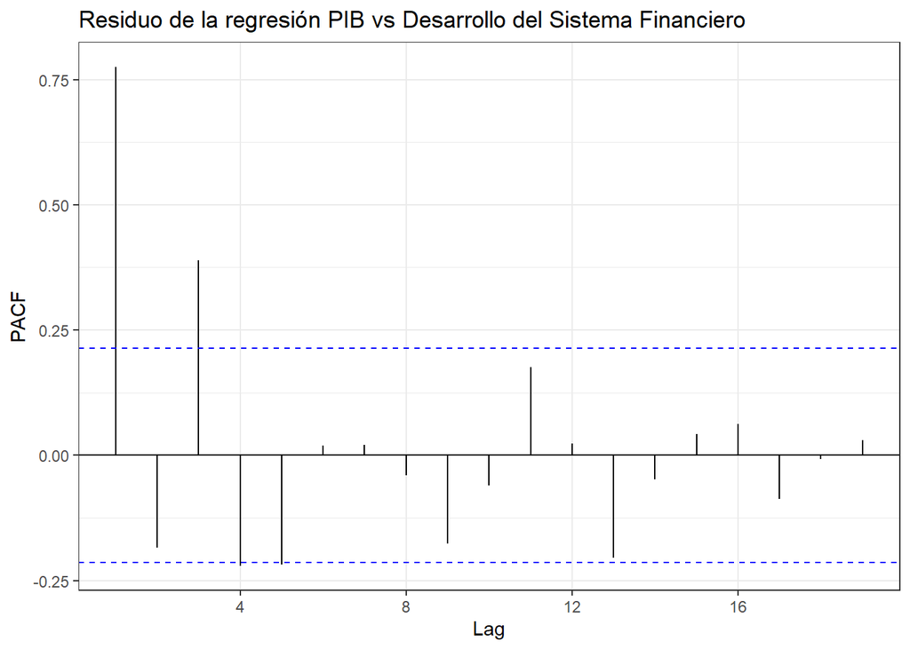

```r
ggPacf(res_ts) +
  ggtitle("Residuo de la regresión PIB vs Desarrollo del Sistema Financiero") +
  theme_bw()
```

## Modelo VAR

**Características del modelo:**

- Se definen 5 rezagos, con base al criterio de Akaike.
- Se incluyen las variables exógenas: Apertura Comercial, Inversión Extranjera Directa, Inflación. En el caso de las variables de apertura comercial e inflación, se crearon variables dicotómicas para corregir autocorrelación en el residuo. En apertura comercial, valores mayores a 75% del PIB se definieron con 1, 0 caso contrario. Para inflación, el valor de 1 se definió para montos mayores a 7%.
- Se incluye 1 variable dicotómica para capturar el valor extremo en la variable PIB real asociado a la pandemia.
- Se incluye la constante como variable determinística.

```r
mod_var <- VAR(cbind(pib_ts, cred_pib_ts),
           type = "const",
           lag.max = 12, ic = "AIC",
           exogen = cbind(covariables, d_2Q20_ts)
           )
```

```r
summary(mod_var)
```

```
##
## VAR Estimation Results:
## =========================
## Endogenous variables: pib_ts, cred_pib_ts
## Deterministic variables: const
## Sample size: 79
## Log Likelihood: -707.894
## Roots of the characteristic polynomial:
## 0.983 0.9686 0.9686 0.9257 0.7529 0.7529 0.5599 0.5599 0.5585 0.5585
## Call:
## VAR(y = cbind(pib_ts, cred_pib_ts), type = "const", exogen = cbind(covariables,
##     d_2Q20_ts), lag.max = 12, ic = "AIC")
##
##
## Estimation results for equation pib_ts:
## =======================================
## pib_ts = pib_ts.l1 + cred_pib_ts.l1 + pib_ts.l2 + cred_pib_ts.l2 + pib_ts.l3 + cred_pib_ts.l3 + pib_ts.l4 + cred_pib_ts.l4 + pib_ts.l5 + cred_pib_ts.l5 + const + covariables.apertcomercial75_ts + covariables.inflacion7_ts + covariables.ied_ts + d_2Q20_ts
##
##                                   Estimate Std. Error t value Pr(>|t|)
## pib_ts.l1                        7.194e-01  7.866e-02   9.146 3.15e-13 ***
## cred_pib_ts.l1                  -1.575e+06  1.584e+06  -0.994 0.323785
## pib_ts.l2                       -2.111e-01  9.674e-02  -2.182 0.032798 *
## cred_pib_ts.l2                   4.943e+06  2.667e+06   1.853 0.068455 .
## pib_ts.l3                        2.429e-01  1.125e-01   2.159 0.034640 *
## cred_pib_ts.l3                  -5.846e+06  2.719e+06  -2.150 0.035341 *
## pib_ts.l4                        6.210e-01  1.182e-01   5.255 1.81e-06 ***
## cred_pib_ts.l4                   5.281e+06  2.697e+06   1.958 0.054537 .
## pib_ts.l5                       -4.464e-01  9.703e-02  -4.601 2.04e-05 ***
## cred_pib_ts.l5                  -2.047e+06  1.606e+06  -1.275 0.207028
## const                            2.058e+05  1.077e+05   1.910 0.060563 .
## covariables.apertcomercial75_ts  2.464e+05  7.827e+04   3.149 0.002492 **
## covariables.inflacion7_ts       -2.696e+05  7.699e+04  -3.502 0.000847 ***
## covariables.ied_ts               1.156e+02  6.394e+01   1.808 0.075349 .
## d_2Q20_ts                       -7.238e+05  1.064e+05  -6.801 4.15e-09 ***
## ---
## Signif. codes:  0 '***' 0.001 '**' 0.01 '*' 0.05 '.' 0.1 ' ' 1
##
##
## Residual standard error: 87980 on 64 degrees of freedom
## Multiple R-Squared: 0.9971,  Adjusted R-squared: 0.9964
```

[output cut: 27 more lines]

```
## Residual standard error: 0.0064 on 64 degrees of freedom
## Multiple R-Squared: 0.9967,  Adjusted R-squared: 0.996
## F-statistic:  1395 on 14 and 64 DF,  p-value: < 2.2e-16
##
##
##
## Covariance matrix of residuals:
##                pib_ts cred_pib_ts
## pib_ts      7.740e+09   1.817e+00
## cred_pib_ts 1.817e+00   4.096e-05
##
## Correlation matrix of residuals:
##               pib_ts cred_pib_ts
## pib_ts      1.000000    0.003227
## cred_pib_ts 0.003227    1.000000
```

### Supuestos del Modelo

#### 1. Autocorrelación serial

Con base a la prueba de Portmanteau se concluye que los residuos del modelo no presentan autocorrelación. No obstante, la prueba Breusch-Godfrey indica que los residuos sí presentan autocorrelación.

```r
serial.test(mod_var, lags.pt = 16, type = "PT.asymptotic")
```

```
##
##  Portmanteau Test (asymptotic)
##
## data:  Residuals of VAR object mod_var
## Chi-squared = 52.463, df = 44, p-value = 0.1788
```

```r
serial.test(mod_var, lags.pt = 16, type = "BG")
```

```
##
##  Breusch-Godfrey LM test
##
## data:  Residuals of VAR object mod_var
## Chi-squared = 41.905, df = 20, p-value = 0.002846
```

```r
serial.test(mod_var, lags.pt = 16, type = "PT.adjusted")
```

```
##
##  Portmanteau Test (adjusted)
##
## data:  Residuals of VAR object mod_var
## Chi-squared = 58.6, df = 44, p-value = 0.06934
```

#### 2. Homocedasticidad

Según se constata en la siguiente prueba, el modelo no presenta heterocedasticidad.

```r
arch.test(mod_var, lags.multi = 5, multivariate.only = T)
```

```
##
##  ARCH (multivariate)
##
## data:  Residuals of VAR object mod_var
## Chi-squared = 50.886, df = 45, p-value = 0.2531
```

#### 3. Normalidad del residuo

Los residuos multivariados del modelo siguen una distribución normal.

```r
normality.test(mod_var, multivariate.only = T)
```

```
## $JB
##
##  JB-Test (multivariate)
##
## data:  Residuals of VAR object mod_var
## Chi-squared = 3.5991, df = 4, p-value = 0.463
##
##
## $Skewness
##
##  Skewness only (multivariate)
##
## data:  Residuals of VAR object mod_var
## Chi-squared = 2.3091, df = 2, p-value = 0.3152
##
##
## $Kurtosis
##
##  Kurtosis only (multivariate)
##
## data:  Residuals of VAR object mod_var
## Chi-squared = 1.29, df = 2, p-value = 0.5247
```

[interactive chart not shown]

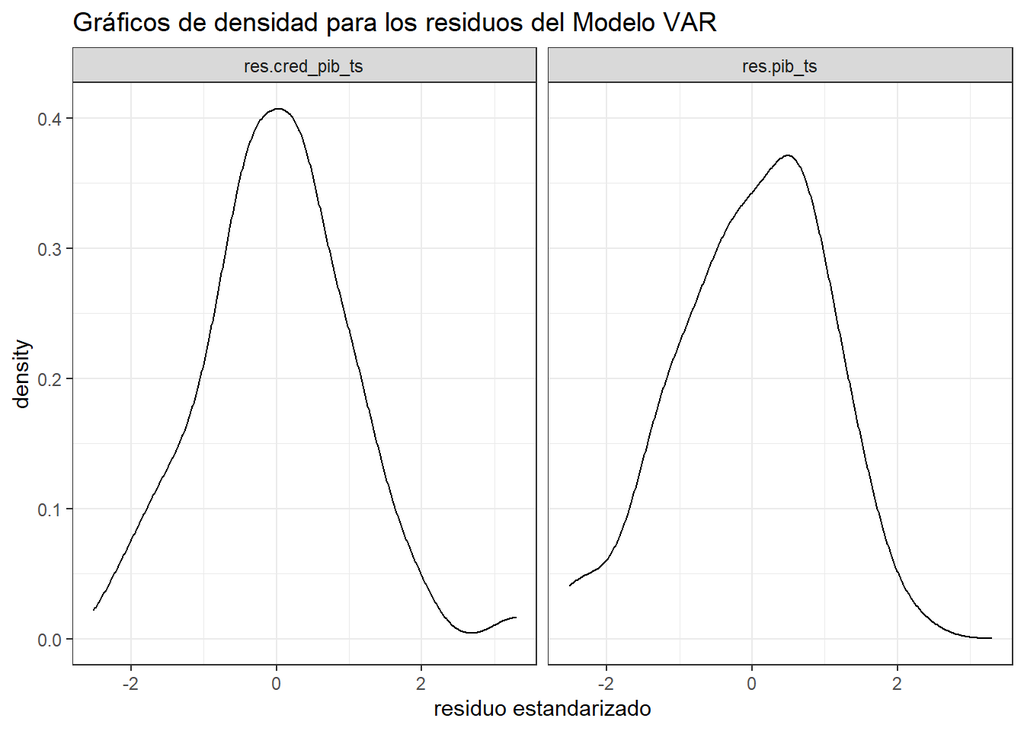

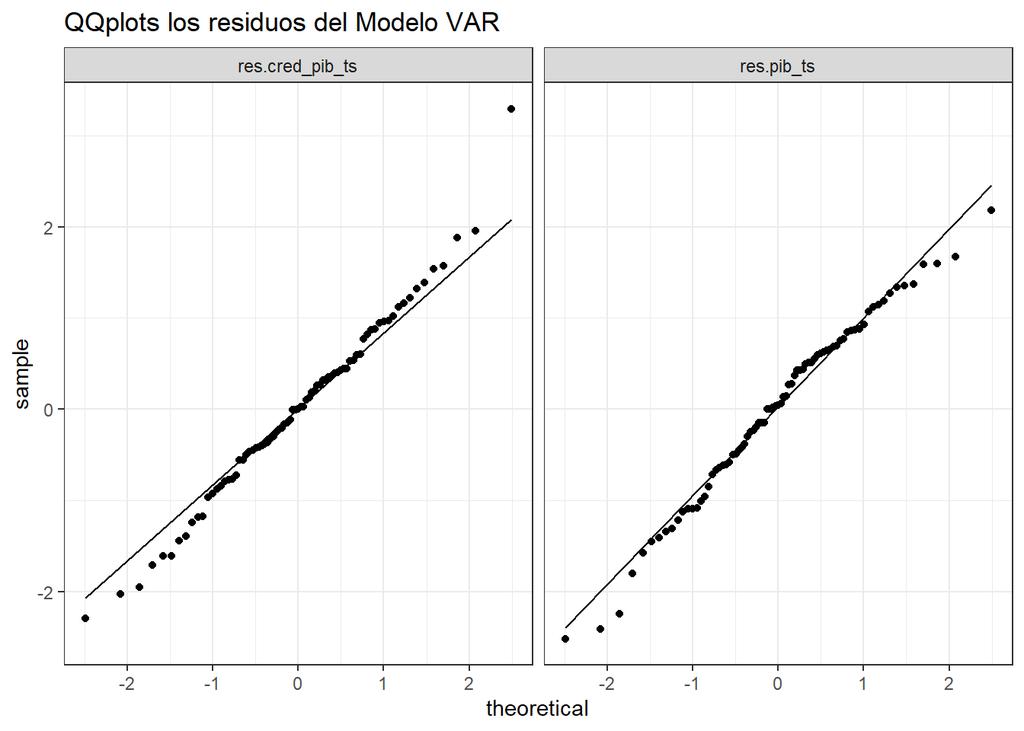

#### 4. Estabilidad

los eigenvalores son menores a 1, por lo cual se concluye que el modelo sí es estable. Esto se reafirma con el gráfico OLS-CUSUM.

```r
roots(mod_var, modulus = T)
```

```
##  [1] 0.9830120 0.9686238 0.9686238 0.9257129 0.7528973 0.7528973 0.5598767
##  [8] 0.5598767 0.5585374 0.5585374
```

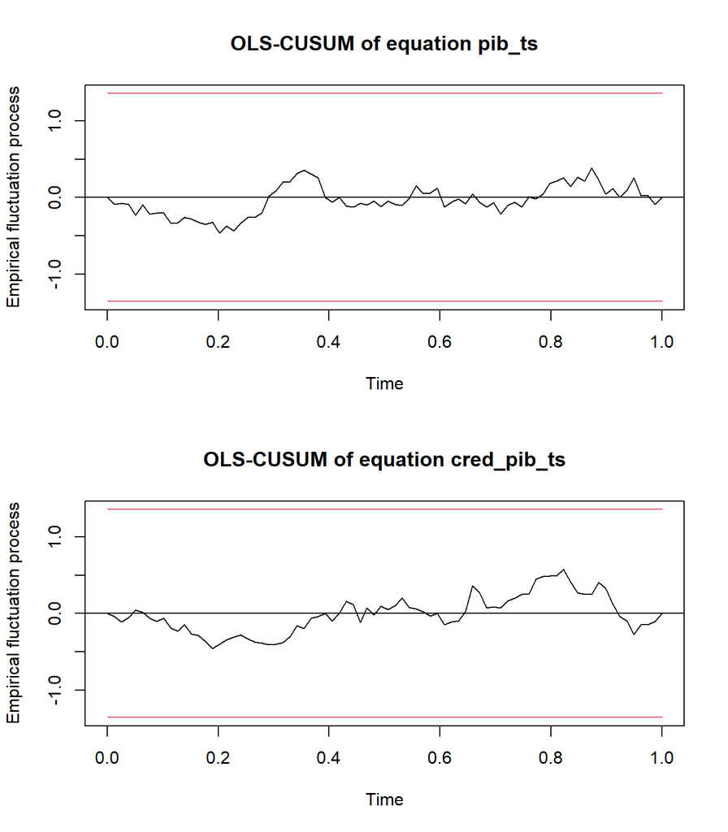